# Component 4: Commute times with ATUS

## Purpose

The purpose of this model is to explore relationships between commute time and other respondent characteristics, such as income, age, and time spent with family. Commute time has the potential to negatively impact mental health and take time away from other aspects of a person’s life such as time spent with friends or family. I apply both unsupervised and supervised learning to look for possible biases in commmute time. For example, is a longer commute time a socioeconomic burden or are long commutes associated with more valuable employment?

## Data

I use data from the [2017 American Time Use Survey Data](https://www.bls.gov/tus/datafiles_2017.htm), specifically the activity, roster, and respondent files. I restricted the dataset to respondents who identified the type of vehicle for their commute (bus, train, walking, car), which resulted in 5386 observations included out of 10,223 in the full dataset. First, I clustered commutes by characteristics (time, duration, type). I joined commute data to respondent data to calculate total commute time per person per day and used that as the outcome variable for a predictive model. Attributes were chosen for the predictive model based on relevance to quality of life or socioeconomic status, and then filtered for data coverage. Data covereage brought the sample size to 1324 participants. No other transformations were made to the data.

## Limits on validity and generalizability

This model has some weakness in validity and generalizability. The American Time Use survey was not designed to measure commute details, so an assumption has been made that “work related travel” indicates a daily commute for the majority of participants. Also, problems with the reporting of location during the commute mean that of the 10,000 or so participants, only 5386 were included in the clustering and 1324 in the predictive model in a nonrandom manner. However the sample size is still relatively large and comes from a representative sample of the US population, so that patterns found here would be a good starting point for further investigation.

## Outcome: no strong relationship

```r
# load libraries

library(kernlab)
library(dbscan)
library(diceR) # For cluster analysis and ensemble cluster
library(clValid) # For cluster analysis and validation measures
library(pander) # For tables
library(ggpubr)
library(tidyverse)
library(checkpoint)
```

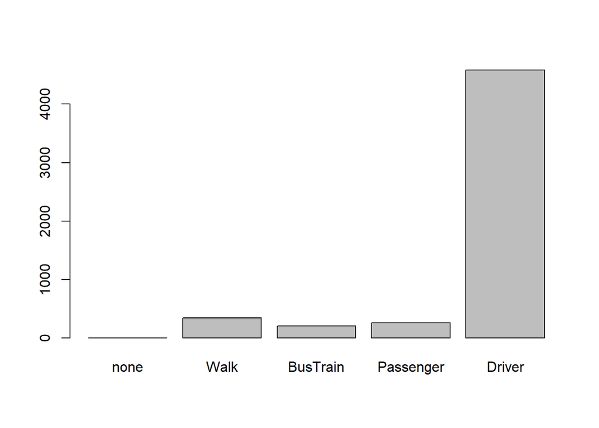

```r
library(lmSupport)
library(ggplot2)
library(ggExtra)
library(chron)
library(caret)
# load data

# activity data
d = read.delim("atusact_2017.dat", header = TRUE, sep =",")

#convert times to times
d$TUSTARTTIM = chron(times.= d$TUSTARTTIM, format = "hh:mm:ss")
d$TUSTOPTIME = chron(times.= d$TUSTOPTIME, format = "hh:mm:ss")

# filter to commutes
wktrav = c(180501, 180502, 180503)

d = filter(d, d$TRCODE %in% wktrav)


# now filter by type of travel
# Count  Code  Description
# 4619     12    Car, truck, or motorcycle (driver)
#  260     13    Car, truck, or motorcycle (passenger)
#  354     14    Walking
#  104     15    Bus
#  105     16    Subway/train

# Add column DRIVER for driver of car, truck, motorcycle
d$DRIVER = 0
d$DRIVER[d$TEWHERE == 12] = 1

# Add column PSNGR for passenger in car, truck, motorcycle
d$PSNGR = 0
d$PSNGR[d$TEWHERE == 13] = 1

# Add column WALK
d$WALK = 0
d$WALK[d$TEWHERE == 14] = 1

# Add column BSTR for Bus or Train or Subway
d$BSTR = 0
d$BSTR[d$TEWHERE %in% c(15,16)] = 1

# Add a column TRAVTYPE where 1 = walk, 2 = Bus/train, 3 = passenger, 4 = car/truck/motorbike
d$TRAVTYPE = 0
d$TRAVTYPE[d$TEWHERE == 12] = 4
d$TRAVTYPE[d$TEWHERE == 13] = 3
d$TRAVTYPE[d$TEWHERE == 14] = 1
d$TRAVTYPE[d$TEWHERE %in% c(15,16)] = 2
d$TRAVTYPE = factor(d$TRAVTYPE)
levels(d$TRAVTYPE) = c("none", "Walk", "BusTrain", "Passenger", "Driver")

# remove datapoints that aren't in one of your 4 transport groups
d = d[d$TRAVTYPE %in% c("Walk", "BusTrain", "Passenger", "Driver"), ]

plot(d$TRAVTYPE)
```

```r
str(d)
```

```
## 'data.frame':    5386 obs. of  35 variables:
##  $ TUCASEID    : num  2.02e+13 2.02e+13 2.02e+13 2.02e+13 2.02e+13 ...
##  $ TUACTIVITY_N: int  3 10 1 3 11 33 35 9 13 8 ...
##  $ TEWHERE     : int  12 12 12 12 12 12 12 12 12 12 ...
##  $ TRTCCTOT_LN : int  0 0 0 0 0 0 0 0 0 0 ...
##  $ TRTCC_LN    : int  -1 -1 -1 -1 0 -1 -1 -1 -1 0 ...
##  $ TRTCOC_LN   : int  0 0 0 0 0 0 0 0 0 0 ...
##  $ TRTEC_LN    : int  -1 -1 -1 -1 -1 -1 -1 -1 -1 -1 ...
##  $ TRTHH_LN    : int  -1 -1 -1 -1 0 -1 -1 -1 -1 0 ...
##  $ TRTNOHH_LN  : int  -1 -1 -1 -1 -1 -1 -1 -1 -1 0 ...
##  $ TRTOHH_LN   : int  -1 -1 -1 -1 0 -1 -1 -1 -1 -1 ...
##  $ TRTONHH_LN  : int  -1 -1 -1 -1 -1 -1 -1 -1 -1 -1 ...
##  $ TRTO_LN     : int  -1 -1 -1 -1 0 -1 -1 -1 -1 -1 ...
##  $ TUACTDUR    : int  15 45 105 105 20 25 25 15 15 30 ...
##  $ TUACTDUR24  : int  15 45 105 105 20 25 25 15 15 30 ...
```

[output cut: 23 more lines]

```r
# Ok, now let's bring in the demographic information

# Respondent info!
dresp = read.delim("atusresp_2017.dat", header = TRUE, sep =",")

# Roster info -- need this to get age!
drost = read.delim("atusrost_2017.dat", header = TRUE, sep =",")

# Filter out just the respondents, remove their household members -- TULINENO = 1
drost = filter(drost, TULINENO == 1)
# we want their age
dage = select(drost, TUCASEID, TEAGE)

# join age and respondent info with the activity data
d = left_join(d, dage, by = "TUCASEID")
d = left_join(d, dresp, by = "TUCASEID")


# filter to people who are employed
# value of 1 or 2 for TELFS (labor force status)
# d = filter(d, d$TELFS %in% c(1,2))
```

```r
# cluster

# which variables are we interested in
col3 = c('TUACTDUR', 'TUSTARTTIM','TUSTOPTIME', "DRIVER", "PSNGR", "WALK", "BSTR")

# Build a kmeans model
# scale the variables related to the clustering
dscale = d
dscale[, col3] = scale(d[,col3])

# kmeans
d$km.cluster  =  kmeans(dscale[, col3], centers = 6)$cluster %>%
  as.factor()
```

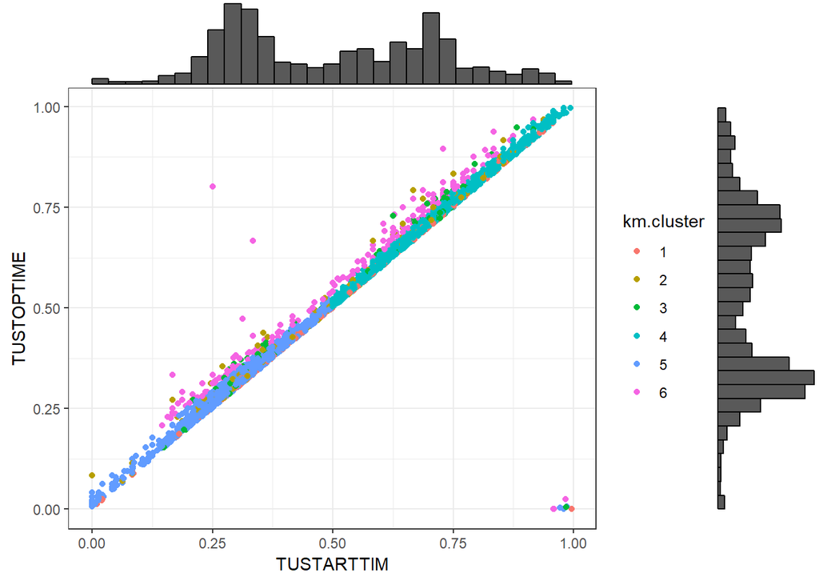

```r
# cluster visualizations

# plot start and end times
times.plot = ggplot(d, aes(TUSTARTTIM, TUSTOPTIME, colour = km.cluster)) +
  geom_point() +
  theme_bw()
ggMarginal(times.plot, type="histogram")
```

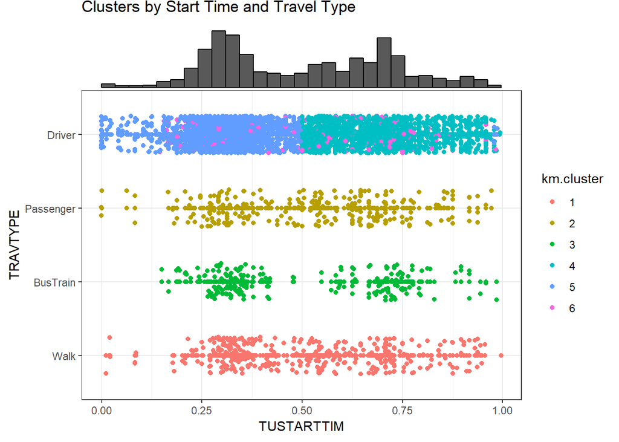

```r
# plot start time and travel type
types.plot = ggplot(d, aes(TUSTARTTIM, TRAVTYPE, colour = km.cluster)) +
  geom_point() +
  theme_bw() +
  geom_jitter(stat = "identity",
              height = 0.25) +
  labs(title = "Clusters by Start Time and Travel Type", xlab = "Start time of work travel", ylab = "Travel type")

ggMarginal(types.plot, type="histogram", margins = "x")
```

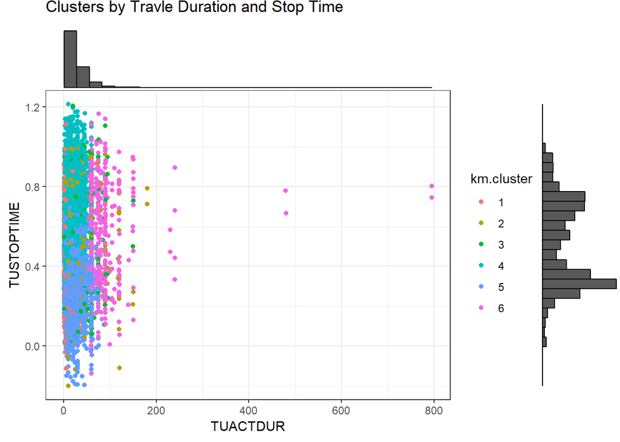

```r
# plot duration and stop time
dur.plot = ggplot(d, aes(TUACTDUR, TUSTOPTIME, colour = km.cluster)) +
  geom_point() +
  theme_bw() +
  geom_jitter(stat = "identity",
              height = 0.25) +
  labs(title = "Clusters by Travle Duration and Stop Time", xlab = "Stop Time", ylab = "Travel Duration")

ggMarginal(dur.plot, type="histogram")
```

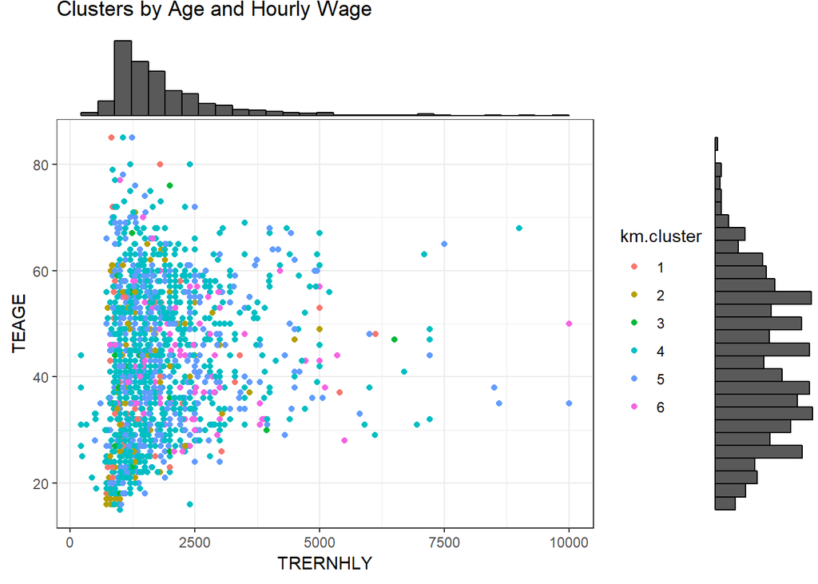

```r
# Now let's see if these clusters of commute categories show differences in age or hourly wage

# wage of clusters
wage.plot = ggplot(d[d$TRERNHLY > 0,], aes(TRERNHLY, TEAGE, colour = km.cluster)) +
  geom_point() +
  theme_bw() +
  # geom_jitter(stat = "identity",
  #             height = 0.25) +
  labs(title = "Clusters by Age and Hourly Wage", xlab = "Hourly Earnings", ylab = "Travel type")

ggMarginal(wage.plot, type="histogram", margins = "both")
```

There is no trend in cluster assignment related to age or hourly earnings.

```r
# Predict total commute time

# Sum commute time per respondent

totdur = d %>%
  group_by(TUCASEID) %>%
  summarise(tot = sum(TUACTDUR), travcount = n())

# join on demographics and other... stuff
totdur = left_join(totdur, dage, by = "TUCASEID")
totdur = left_join(totdur, dresp, by = "TUCASEID")
```

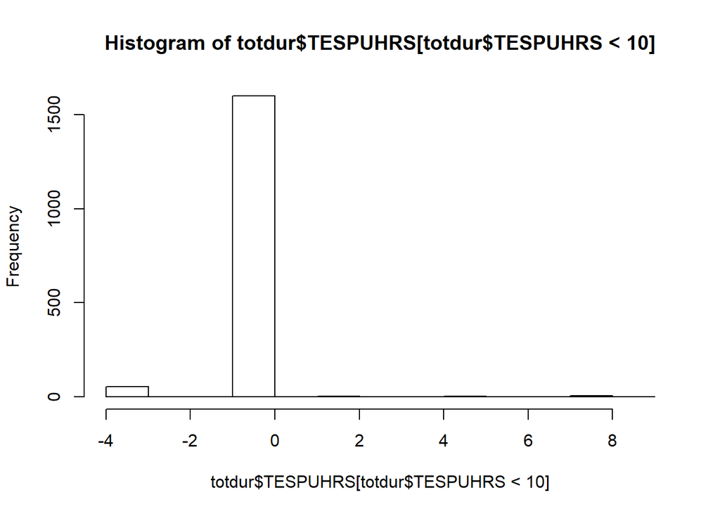

```r
# cleaning the data

# Ok, we have some columns of interest but the data needs to be cleaned. A value of -1 indicates missing data.


# First let's take care of spouse working hours!
# if they have no spouse their spouse works 0 hours
totdur$TESPUHRS[totdur$TRSPPRES == 3] = 0

# If their spouse is not employed their spouse works 0 hours
totdur$TESPUHRS[totdur$TESPEMPNOT == 2] = 0

# Let's check on what's left
hist(totdur$TESPUHRS[totdur$TESPUHRS < 10])
```

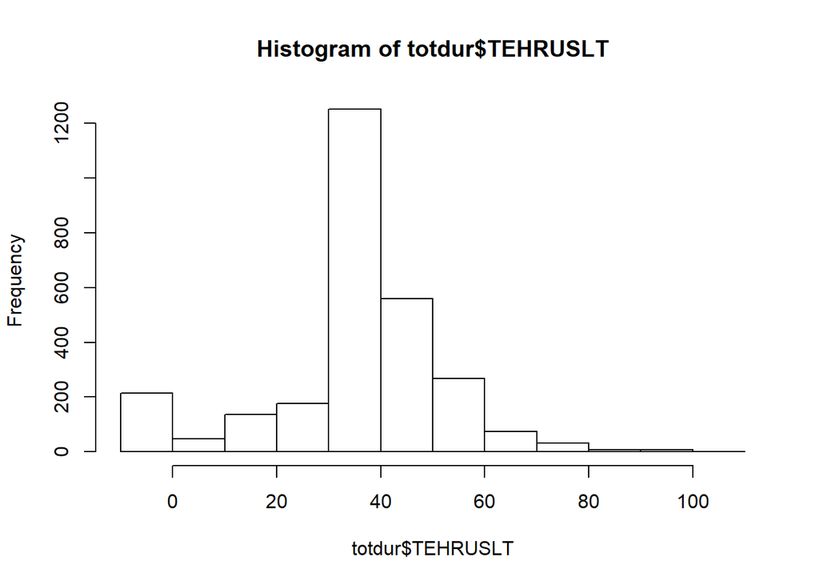

```r
# ok let's remove the spouses with varying hours
totdur = filter(totdur, totdur$TESPUHRS >= 0)

# Next, let's take care of total hours usually worked per week
hist(totdur$TEHRUSLT)
```

```r
totdur = filter(totdur, totdur$TEHRUSLT >= 0)

# Next hourly earnings! There's no way except to remove data points without data
totdur = filter(totdur, totdur$TRERNHLY >= 0)

# We're left with 1324 observations out of 10,000.

# Ok let's cut totdur down only to the columns we want in the model
colt = c('TUCASEID',  "tot", "TEAGE",   'TEHRUSLT', 'TESPUHRS', 'TRCHILDNUM', 'TRERNHLY',
         'TRTALONE',    'TRTCHILD', 'TRTFAMILY',    'TRTFRIEND')

totdur = totdur[,colt]

varDescribe(totdur)
```

|  | vars | n | mean | sd | median | min | max | skew | kurtosis |
| --- | --- | --- | --- | --- | --- | --- | --- | --- | --- |
| TUCASEID | 1 | 1324 | 2.017062e+13 | 359527630.09 | 2.017061e+13 | 2.01701e+13 | 2.017121e+13 | 0.14 | -1.29 |
| tot | 2 | 1324 | 4.224000e+01 | 40.49 | 3.000000e+01 | 1.00000e+00 | 5.250000e+02 | 3.50 | 23.44 |
| TEAGE | 3 | 1324 | 4.303000e+01 | 13.98 | 4.200000e+01 | 1.60000e+01 | 8.500000e+01 | 0.18 | -0.71 |
| TEHRUSLT | 4 | 1324 | 3.914000e+01 | 11.83 | 4.000000e+01 | 2.00000e+00 | 1.050000e+02 | 0.18 | 2.61 |
| TESPUHRS | 5 | 1324 | 1.542000e+01 | 20.82 | 0.000000e+00 | 0.00000e+00 | 9.900000e+01 | 0.86 | -0.45 |
| TRCHILDNUM | 6 | 1324 | 8.100000e-01 | 1.07 | 0.000000e+00 | 0.00000e+00 | 6.000000e+00 | 1.27 | 1.04 |
| TRERNHLY | 7 | 1324 | 1.847490e+03 | 1097.82 | 1.501500e+03 | 2.13000e+02 | 9.999000e+03 | 2.34 | 8.10 |
| TRTALONE | 8 | 1324 | 2.306300e+02 | 163.90 | 1.950000e+02 | 0.00000e+00 | 1.032000e+03 | 0.93 | 0.67 |
| TRTCHILD | 9 | 1324 | 8.895000e+01 | 142.36 | 0.000000e+00 | 0.00000e+00 | 9.000000e+02 | 1.99 | 4.47 |
| TRTFAMILY | 10 | 1324 | 1.580400e+02 | 168.78 | 1.200000e+02 | 0.00000e+00 | 9.000000e+02 | 1.09 | 0.94 |

[output cut: 1 more lines]

```r
#interested variables
# tot          total commute
# TEAGE        age
# TEHRUSLT     hours worked per week
# TESPUHRS     spouse hours
# TRCHILDNUM   num of children
# TRERNHLY     hourly wage
# TRTALONE     time alone
# TRTCHILD     time with kids
# TRTFAMILY    time with family
# TRTFRIEND    time with friends
```

```r
#Partition Data into Training and Testing

# creates a vector of which rows are in the test group
inTrain = createDataPartition(totdur$tot, p = 4/5, list = FALSE)

# pull out the test data for every variable except the one you're predicting
trainDescr =totdur[inTrain,] # All but class variable
testDescr = totdur[-inTrain,]
```

```r
## Linear regression
lm.fit = train(tot ~ ., data = trainDescr,
               method = "lm",
               trControl = trainControl(method = "repeatedcv", number = 10, repeats = 5))
print(lm.fit)
```

```
## Linear Regression
##
## 1060 samples
##   10 predictor
##
## No pre-processing
## Resampling: Cross-Validated (10 fold, repeated 5 times)
## Summary of sample sizes: 953, 953, 954, 954, 954, 955, ...
## Resampling results:
##
##   RMSE      Rsquared    MAE
##   39.56672  0.03402914  26.20563
##
## Tuning parameter 'intercept' was held constant at a value of TRUE
```

```r
## xgboost
xgb.fit = train(tot ~ ., data = trainDescr,
                method = "xgbTree",
                trControl = trainControl(method = "repeatedcv", number = 10, repeats = 5))
print(xgb.fit)
```

```
## eXtreme Gradient Boosting
##
## 1060 samples
##   10 predictor
##
## No pre-processing
## Resampling: Cross-Validated (10 fold, repeated 5 times)
## Summary of sample sizes: 955, 953, 953, 955, 953, 955, ...
## Resampling results across tuning parameters:
##
##   eta  max_depth  colsample_bytree  subsample  nrounds  RMSE
##   0.3  1          0.6               0.50        50      39.80743
##   0.3  1          0.6               0.50       100      40.17479
##   0.3  1          0.6               0.50       150      40.45279
##   0.3  1          0.6               0.75        50      39.56908
##   0.3  1          0.6               0.75       100      39.82923
##   0.3  1          0.6               0.75       150      40.12913
##   0.3  1          0.6               1.00        50      39.33732
##   0.3  1          0.6               1.00       100      39.72109
##   0.3  1          0.6               1.00       150      40.12268
##   0.3  1          0.8               0.50        50      39.91019
##   0.3  1          0.8               0.50       100      40.03097
##   0.3  1          0.8               0.50       150      40.25012
##   0.3  1          0.8               0.75        50      39.57445
##   0.3  1          0.8               0.75       100      39.77628
##   0.3  1          0.8               0.75       150      40.22700
##   0.3  1          0.8               1.00        50      39.40605
##   0.3  1          0.8               1.00       100      39.84014
##   0.3  1          0.8               1.00       150      40.26710
##   0.3  2          0.6               0.50        50      41.80473
##   0.3  2          0.6               0.50       100      43.17325
##   0.3  2          0.6               0.50       150      43.86415
##   0.3  2          0.6               0.75        50      42.05912
##   0.3  2          0.6               0.75       100      43.43416
##   0.3  2          0.6               0.75       150      44.36246
##   0.3  2          0.6               1.00        50      41.66259
##   0.3  2          0.6               1.00       100      43.40803
##   0.3  2          0.6               1.00       150      44.22578
##   0.3  2          0.8               0.50        50      41.97835
##   0.3  2          0.8               0.50       100      43.52373
```

[output cut: 181 more lines]

```
##   0.02252822  32.79820
##   0.03286021  29.03574
##   0.02781418  30.74106
##   0.02619068  31.74003
##   0.02947924  28.61278
##   0.02901535  29.67043
##   0.02754713  30.44432
##
## Tuning parameter 'gamma' was held constant at a value of 0
##
## Tuning parameter 'min_child_weight' was held constant at a value of 1
## RMSE was used to select the optimal model using the smallest value.
## The final values used for the model were nrounds = 50, max_depth = 1,
##  eta = 0.3, gamma = 0, colsample_bytree = 0.6, min_child_weight = 1
##  and subsample = 1.
```

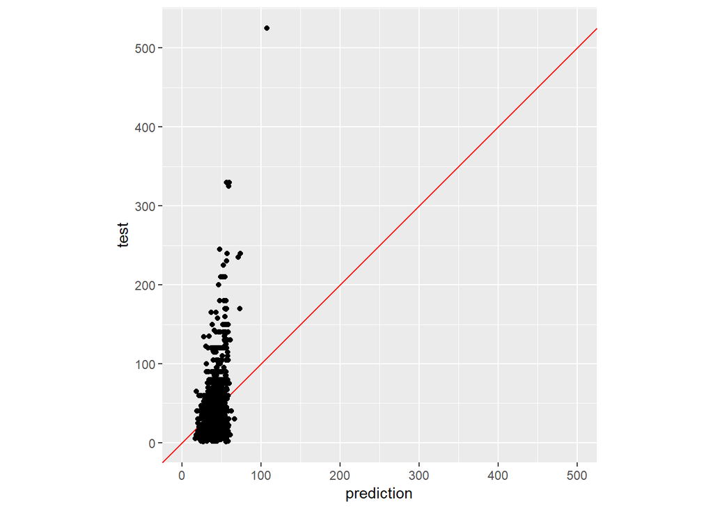

```r
#### Model redictions ####

# xgb
xgb.pred = predict(xgb.fit, totdur)
xgbp = data.frame(prediction = xgb.pred, test = totdur$tot)
ggplot(xgbp, aes(x=prediction, y=test)) + geom_abline(intercept = 0, slope = 1, color = "red") + geom_point() + coord_fixed(ratio = 1, xlim = c(0, 500), ylim = NULL, expand = TRUE,
  clip = "on")
```

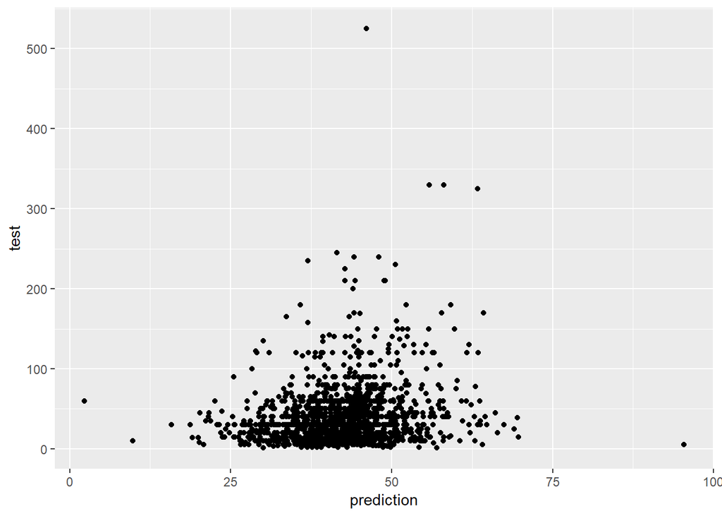

```r
## Model predictions
# lm predictions
lm.pred = predict(lm.fit, totdur)
lmp = data.frame(prediction = lm.pred, test = totdur$tot)
ggplot(lmp, aes(x=prediction, y=test)) + geom_point()
```

```r
#### Compare models ####
mod.resamps = resamples(list(xgb = xgb.fit, lm = lm.fit))
summary(mod.resamps)
```

```
##
## Call:
## summary.resamples(object = mod.resamps)
##
## Models: xgb, lm
## Number of resamples: 50
##
## MAE
##         Min.  1st Qu.   Median     Mean  3rd Qu.     Max. NA's
## xgb 20.63729 24.73258 25.75446 26.26927 27.47787 34.20278    0
## lm  21.27713 24.11749 25.81418 26.20563 28.22484 32.83821    0
##
## RMSE
##         Min.  1st Qu.   Median     Mean  3rd Qu.     Max. NA's
## xgb 27.02108 33.08407 36.81277 39.33732 41.20754 71.76235    0
## lm  26.76144 33.11393 36.90068 39.56672 44.53499 65.72474    0
##
## Rsquared
##             Min.     1st Qu.     Median       Mean    3rd Qu.      Max.
## xgb 7.986355e-04 0.018612777 0.03567500 0.04054434 0.05424816 0.1388330
## lm  1.503972e-07 0.008858974 0.02857203 0.03402914 0.04490112 0.1536914
##     NA's
## xgb    0
## lm     0
```

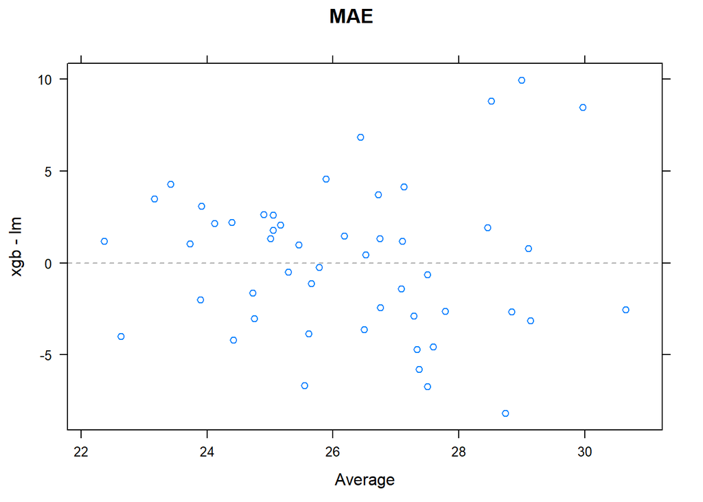

```r
xyplot(mod.resamps, what = "BlandAltman")
```

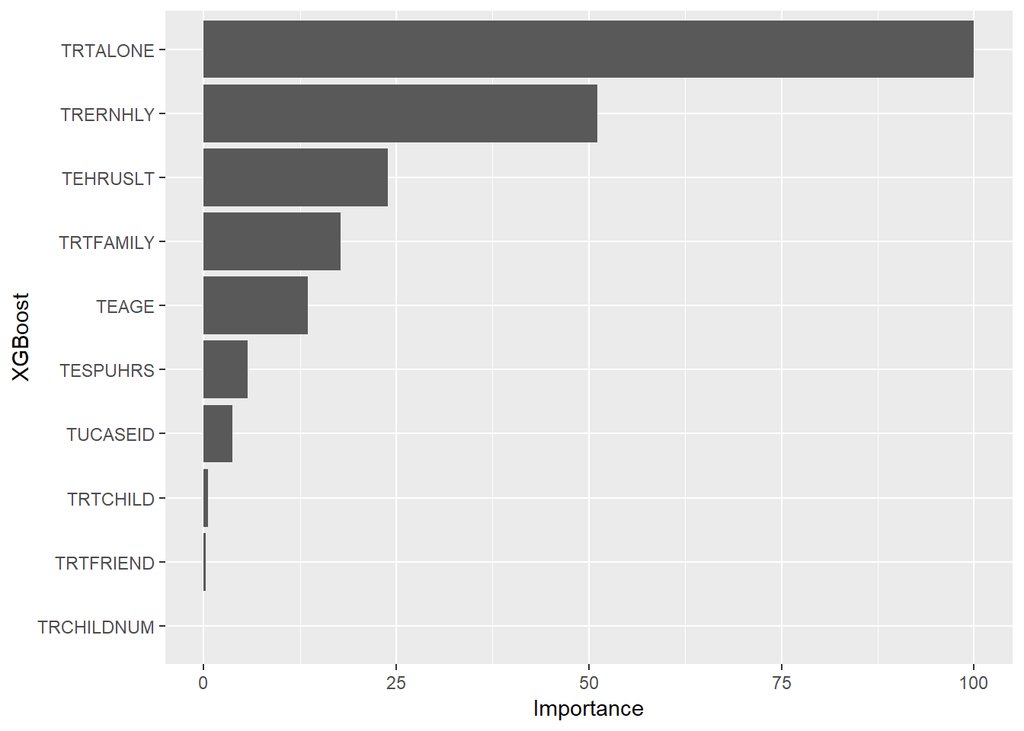

```r
#### Identify important variables ####
ximp = varImp(xgb.fit )

limp = varImp(lm.fit)
 ggplot(data = ximp, aes(x= )) + geom_col(stat = "identity") + xlab("XGBoost")
```

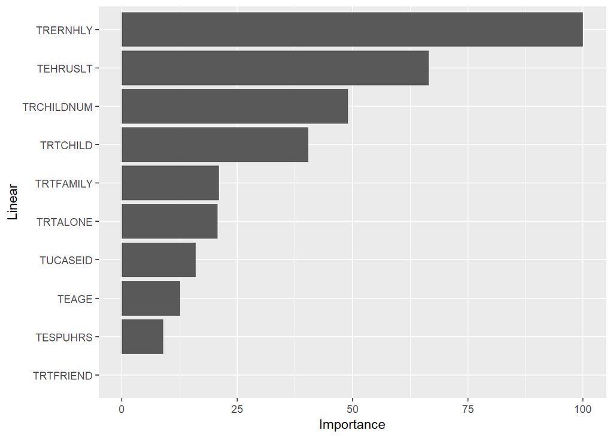

```r
ggplot(data = limp, aes(x= )) + geom_col(stat = "identity") + xlab("Linear")
```